# Module 2 Project: Check Your Numbers

This is the output of one complete run of the project, with a fixed random seed. Use it to see whether your own results are in the right ballpark: the same order of magnitude, the same conclusions, the same first digit or two. It is not an answer key. There is no code and no explanation here, and the exam asks about *your* project, not this one.

What should match, and how closely:

- **Exact values** do not depend on random numbers and should match to every digit shown: the RANDU values in A.1, the wind estimates in A.2, the observed statistics in A.3, B.2 and D.3, the fitted parameters in D.1, and the covariances of the data and the weighted average in D.2.
- **Monte Carlo estimates** vary from run to run. Yours should be close, and where an exact value exists your confidence interval should contain it.
- **Monte Carlo $p$-values** vary too. Yours should lead to the same decision.

# Part A: Inversion

## A.1

$x_1, \ldots, x_{10}$ from seed 406.

```
##  [1]   26608834  159649350  718416594  726171766   38764898  139494438
##  [7]  488082546 1673045334 1350561794 1635897350
```

The QQ plot of 30,000 draws.

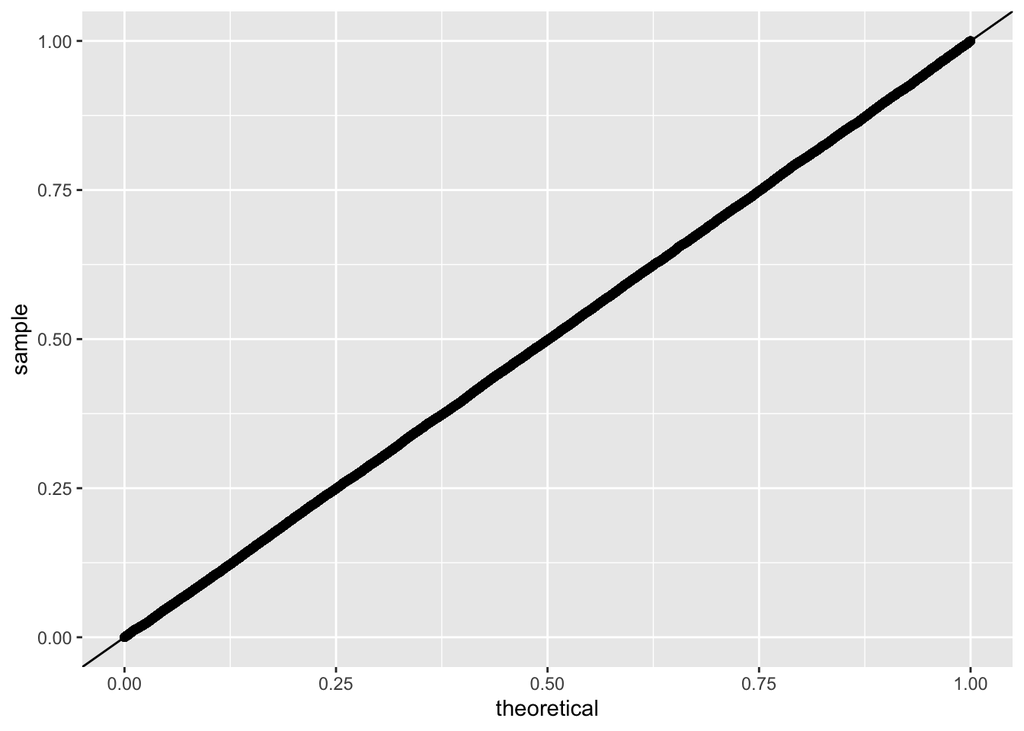

`plot_triples` on the RANDU draws, then on 30,000 `runif` draws.

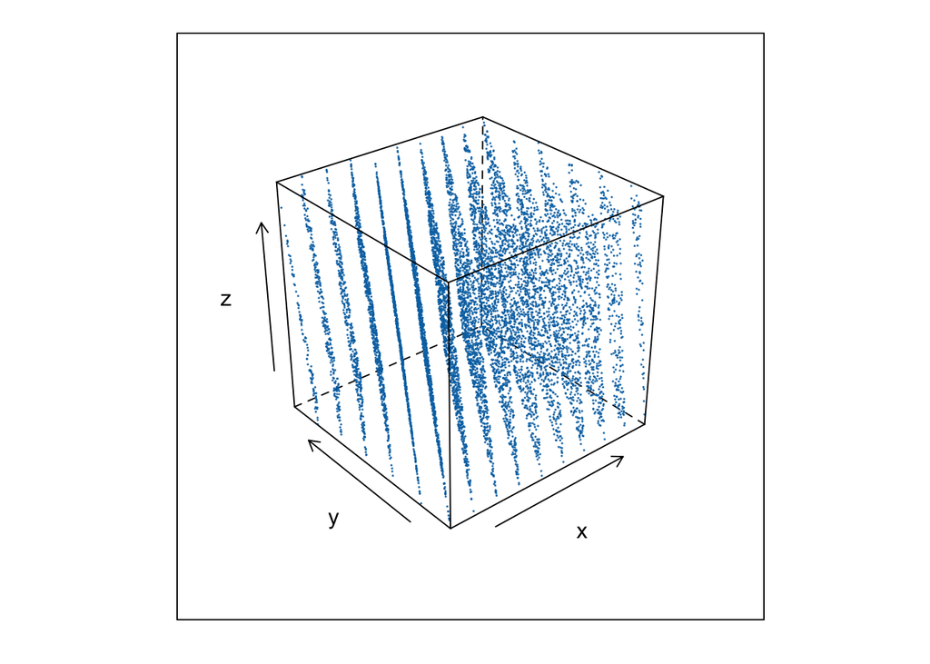

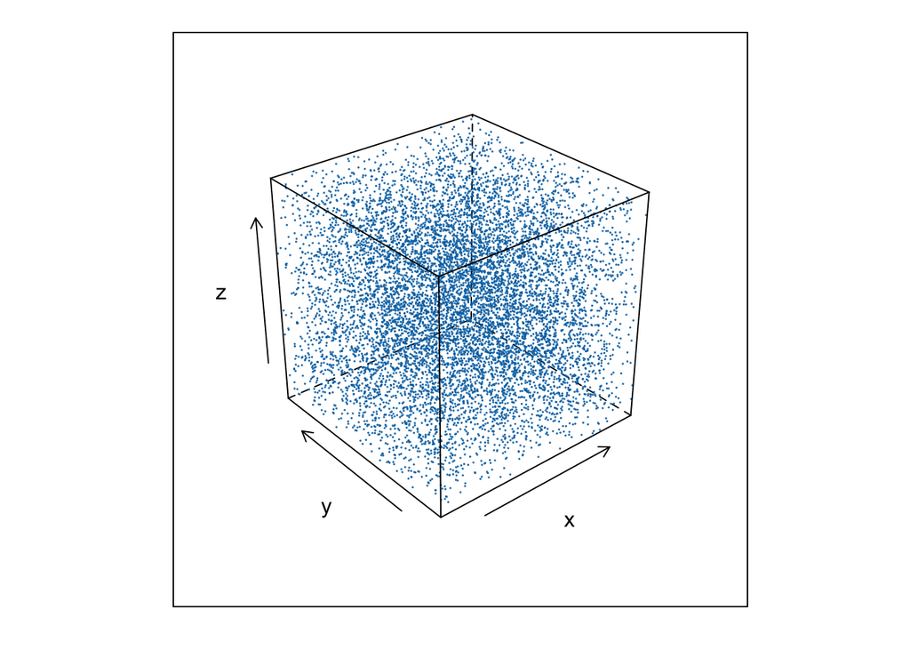

## A.2

The QQ plot of 10,000 draws with $\alpha = 10$, $\beta = 5$.

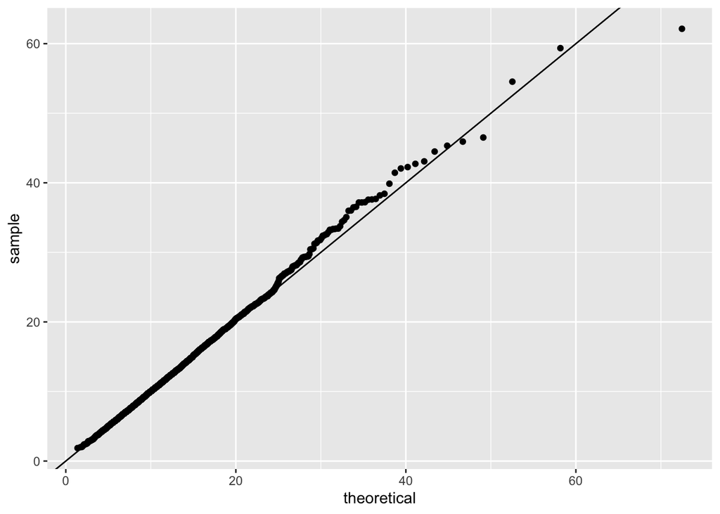

$\hat\alpha$ and $\hat\beta$ for the wind data, then the model’s $P(W > 15)$ beside the fraction of days above 15 mph.

```
##    alpha     beta
## 9.700000 6.454029
```

```
##      model       data
## 0.05660070 0.06535948
```

99% confidence intervals for the bias, then the MSE, of $\hat\beta$ from 1,000 samples.

```
## [1] 0.1223662 0.2847391
## attr(,"conf.level")
## [1] 0.99
```

```
## [1] 0.8834702 1.1766737
## attr(,"conf.level")
## [1] 0.99
```

## A.3

Sampled frequencies from 10,000 draws of `rpois_inv` beside `dpois`.

```
##             0     1     2     3     4     5     6     7     8     9    10
## sampled 0.043 0.143 0.209 0.227 0.176 0.114 0.051 0.024 0.009 0.003 0.001
## exact   0.045 0.140 0.216 0.224 0.173 0.107 0.056 0.025 0.010 0.003 0.001
```

The observed $S^2/\bar X$, then the Monte Carlo $p$-value from 5,000 null samples.

```
## [1] 1.63897
```

```
## [1] 0.00059988
```

# Part B: Transformations and mixtures

## B.1

The QQ plot of 10,000 draws, then the estimate of $P(X > 2)$, its 95% interval, and `pnorm(-2)`.

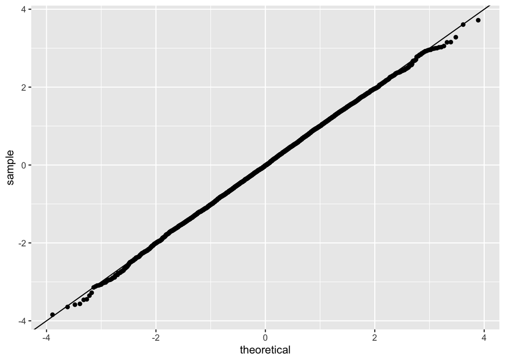

```
##   estimate                            exact
## 0.02020000 0.01744217 0.02295783 0.02275013
```

## B.2

The fitted $\hat\theta$ and $\hat\lambda$, then the expected and observed number of years with no discoveries.

```
##     theta    lambda
## 0.8291053 3.7389703
```

```
## expected observed
## 19.06097  9.00000
```

The Monte Carlo $p$-value from 2,000 samples.

```
## [1] 0.004997501
```

# Part C: Accept-reject and importance resampling

## C.1

The QQ plot of the accepted draws, then the acceptance rate, its 95% interval, and $1/c$.

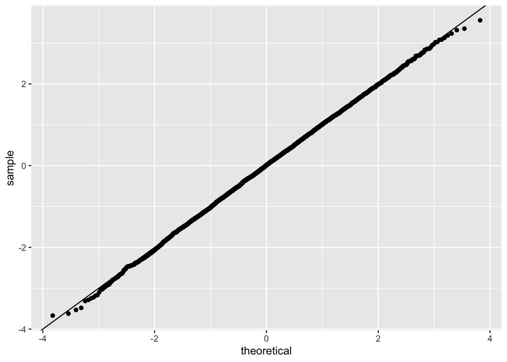

```
##       rate                       one_over_c
##  0.7569000  0.7484912  0.7653088  0.7601735
```

## C.2

The two estimates of $\mathrm{E}(X)$ and the exact value.

```
## accept_reject    resampling         exact
##     0.6381252     0.6274882     0.6304981
```

# Part D: Multivariate distributions and processes

## D.1

$\hat p$, the two component means, then $\hat\Sigma_1$ and $\hat\Sigma_2$.

```
## [1] 0.3566176
```

```
##     eruptions  waiting
## mu1  2.038134 54.49485
## mu2  4.291303 79.98857
```

```
##            eruptions    waiting
## eruptions 0.07121718  0.4522663
## waiting   0.45226632 34.1067440
```

```
##           eruptions    waiting
## eruptions 0.1687990  0.9180667
## waiting   0.9180667 35.9309031
```

272 simulated points beside the data.

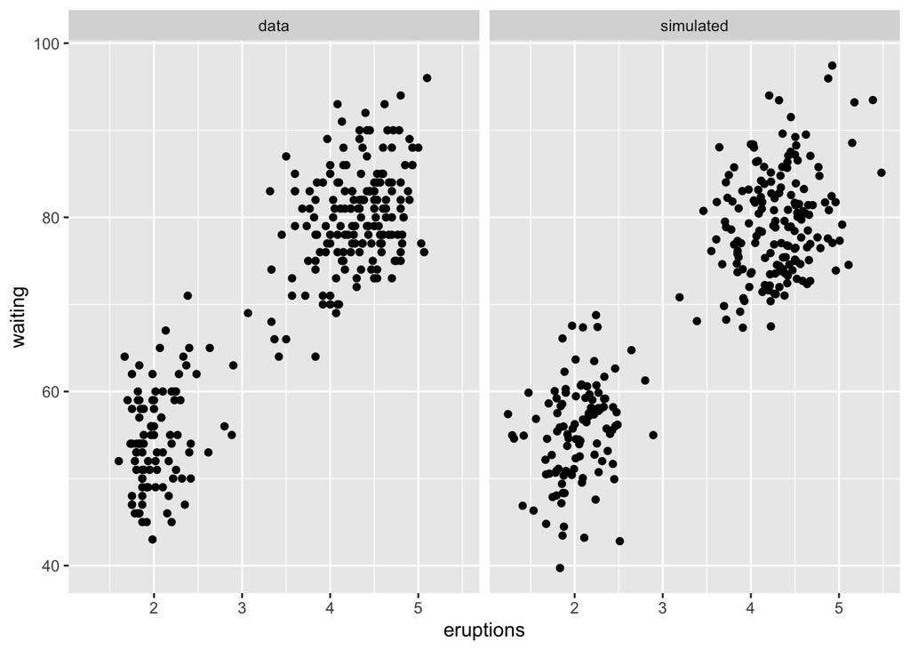

## D.2

`cov(faithful)`, the covariance of 10,000 simulated draws, then $p\Sigma_1 + (1 - p)\Sigma_2$.

```
##           eruptions   waiting
## eruptions  1.302728  13.97781
## waiting   13.977808 184.82331
```

```
##           eruptions   waiting
## eruptions  1.308051  14.13324
## waiting   14.133238 187.77921
```

```
##           eruptions    waiting
## eruptions 0.1339996  0.7519541
## waiting   0.7519541 35.2803758
```

## D.3

$\hat\mu$ and $\hat\sigma$, then 20 simulated paths (gray) with the observed log price (black).

```
##           mu        sigma
## 0.0003401767 0.0130559537
```

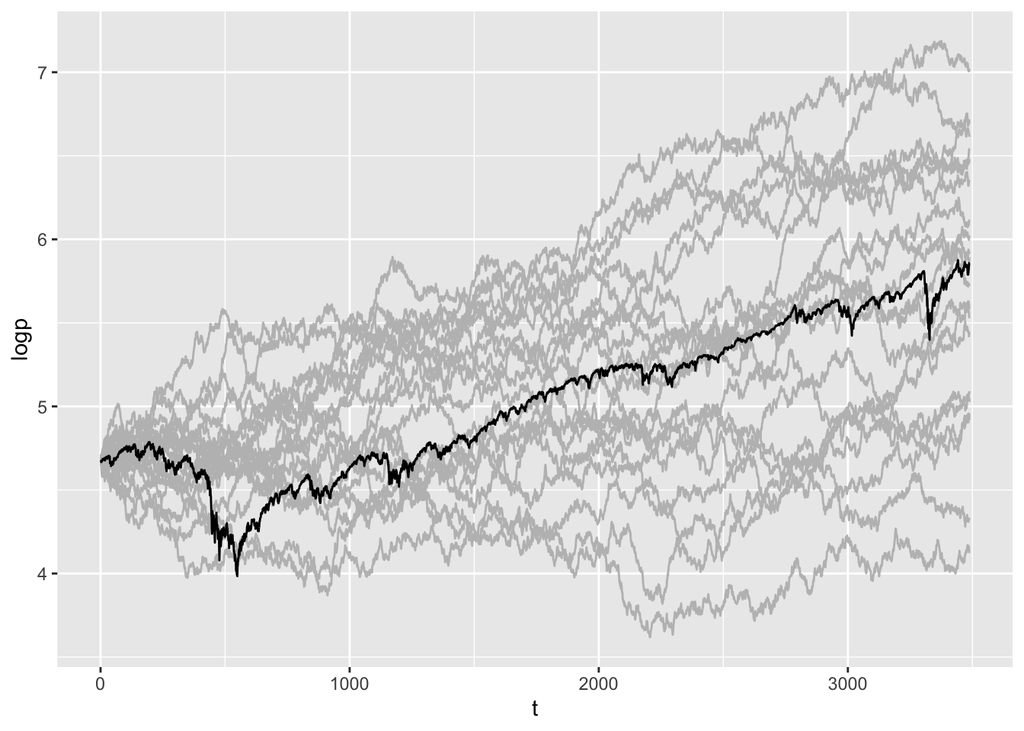

The observed largest drawdown, then its Monte Carlo $p$-value from 1,000 paths.

```
## [1] -0.8027262
```

```
## [1] 0.1768232
```

The observed correlation of $|r_t|$ and $|r_{t-1}|$, then its Monte Carlo $p$-value from the same 1,000 paths.

```
## [1] 0.3457675
```

```
## [1] 0.000999001
```

# Part E: Gibbs sampling

## E.2

The trace plot, then posterior means and 95% credible intervals, then the estimate of $P(\theta_1 / \theta_2 > 2 \mid x)$.

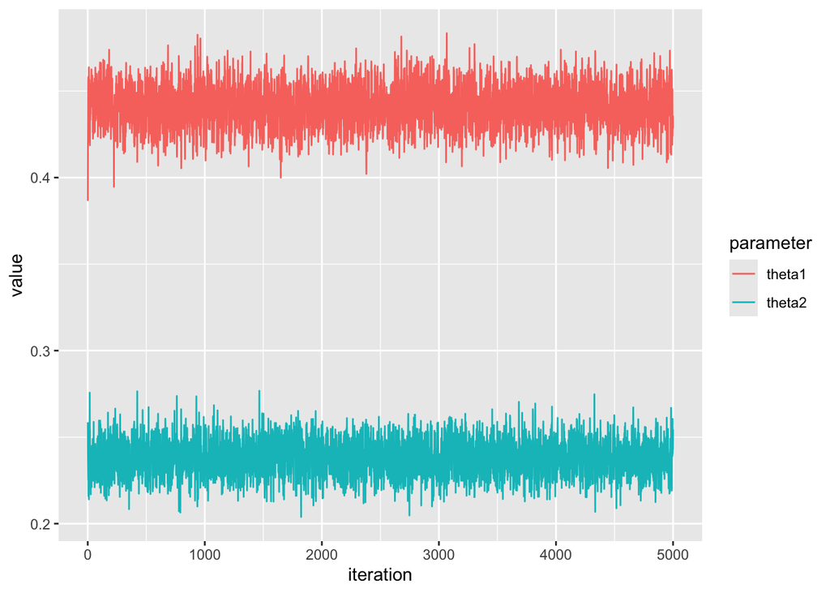

```
##          theta1    theta2    theta3
## mean  0.4413155 0.2379695 0.3207150
## 2.5%  0.4186553 0.2191811 0.2999735
## 97.5% 0.4632780 0.2574575 0.3424197
```

```
## [1] 0.10025
```

## E.3

QQ plots of the direct and the Gibbs draws of $\theta_1$ against the Beta($a_1, a_2 + a_3$) quantile function, then the two estimates of $P(\theta_1 / \theta_2 > 2 \mid x)$.

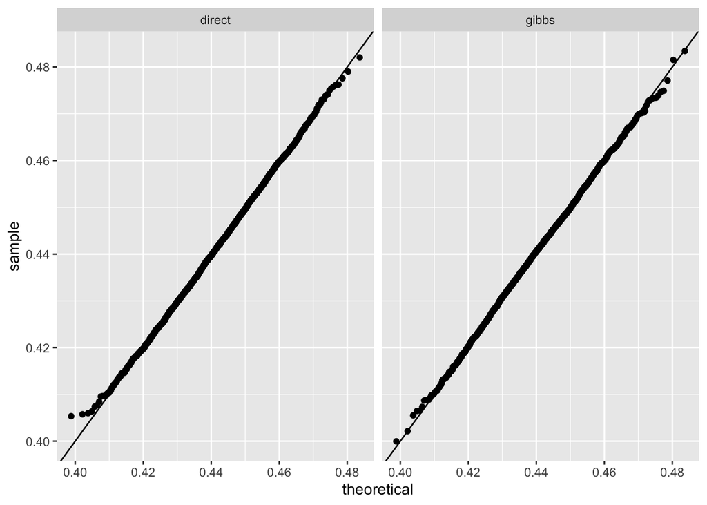

```
##  direct   gibbs
## 0.08900 0.10025
```